# Fraud Detection

Let’s now use these two new balanced data sets to run a 5 folds cross validation for a decision tree for each, checking in which of the two balanced cases the overall performance (including the false positive) improves more with respect to the 5 folds cross validation applied to the imbalanced training data set of before.

5 folds cv with fraud_balanced_over.

```
 recall:

[1] 1

Area under the curve (AUC): 0.962

 confusion matrix


       0    1
  0 3124    0
  1  256 3341

 false positive percentage

[1] 3.808957

 recall:

[1] 1
```

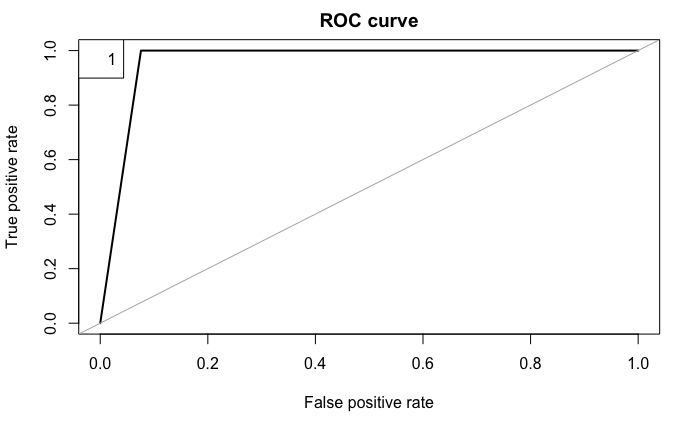

```
Area under the curve (AUC): 0.959

 confusion matrix


       0    1
  0 3101    0
  1  275 3344

 false positive percentage

[1] 4.092262

 recall:

[1] 1
```

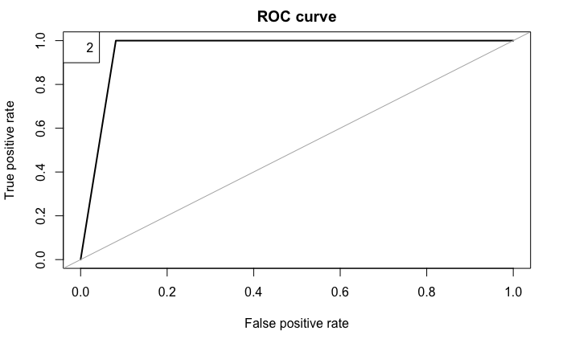

```
Area under the curve (AUC): 0.956

 confusion matrix


       0    1
  0 3030    0
  1  292 3399

 false positive percentage

[1] 4.344592

 recall:

[1] 1
```

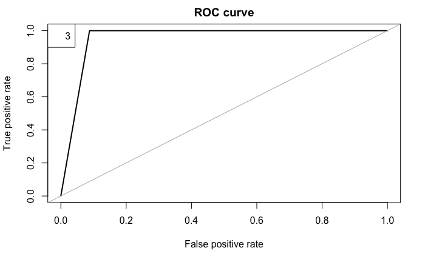

```
Area under the curve (AUC): 0.957

 confusion matrix


       0    1
  0 3063    0
  1  286 3371

 false positive percentage

[1] 4.255952

 recall:

[1] 1
```

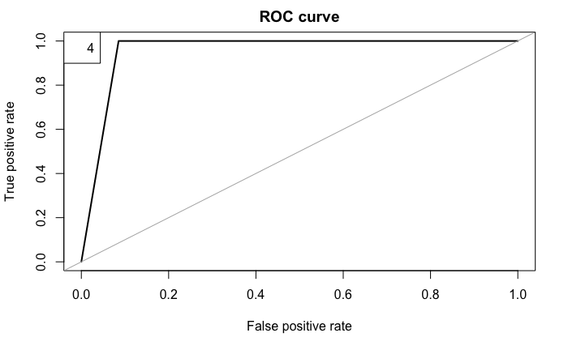

```
Area under the curve (AUC): 0.953

 confusion matrix


       0    1
  0 3096    0
  1  323 3302

 false positive percentage

[1] 4.805832
```

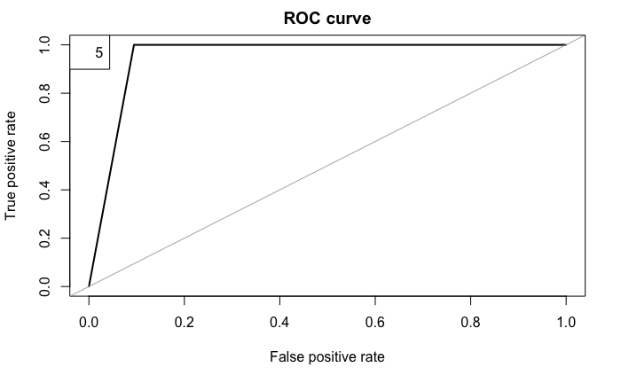

```r
fraud_balanced_over = fraud_balanced_over[sample(nrow(fraud_balanced_over)),]
folds = cut(seq(1,nrow(fraud_balanced_over)),breaks=5,labels=FALSE)
aucover = c()
fppover = c()
rover = c()
for(i in 1:5){

  testIndexes = which(folds==i,arr.ind=TRUE)

  testData = fraud_balanced_over[testIndexes, ]

  trainData = fraud_balanced_over[-testIndexes, ]

  treeover = rpart(is_fraud ~ ., data = trainData)

  pred.treeover = predict(treeover, newdata = testData)

  cat("\n","recall:", "\n", "\n")

  print(accuracy.meas(testData$is_fraud, pred.treeover[,2])$recall)

  cat("\n")

  print(roc.curve(testData$is_fraud, pred.treeover[,2], plotit = TRUE))

  cat("\n","confusion matrix","\n","\n")

  tbover = table(pred.treeover[,2], testData$is_fraud)

  print(tbover)

  legend("topleft", c("fold"), i)

  cat("\n","false positive percentage","\n", "\n")

  print((tbover[2,1]/sum(tbover))*100)

  rover = c(rover, accuracy.meas(testData$is_fraud, pred.treeover[,2])$recall)

  aucover = c(aucover,roc.curve(testData$is_fraud, pred.treeover[,2], plotit = FALSE)$auc)

  fppover = c(fppover,(tbover[2,1]/sum(tbover))*100)
}
```

```r
cat("\n","average recall", mean(rover), "\n")
```

```
 average recall 1
```

```r
cat("\n", "average AUC", mean(aucover), "\n")
```

```
 average AUC 0.9575033
```

```r
cat("\n", "average false positive percentage", mean(fppover))
```

```
 average false positive percentage 4.261519
```

5 folds cv with fraud_balanced_under.

```
 recall:

[1] 0.5384615

Area under the curve (AUC): 0.519

 confusion matrix


    0 1
  0 9 6
  1 9 7

 false positive percentage

[1] 29.03226

 recall:

[1] 0.5625
```

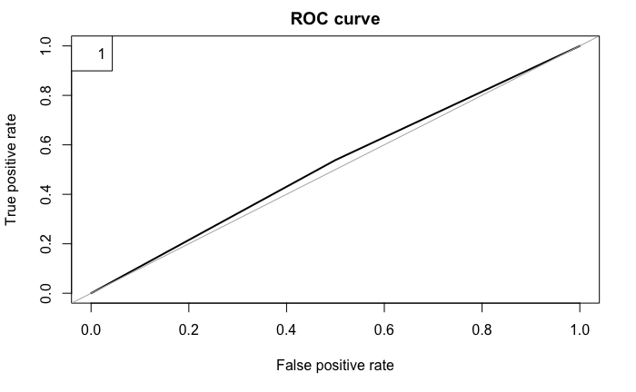

```
Area under the curve (AUC): 0.748

 confusion matrix


     0  1
  0 14  7
  1  1  9

 false positive percentage

[1] 3.225806

 recall:

[1] 0.6923077
```

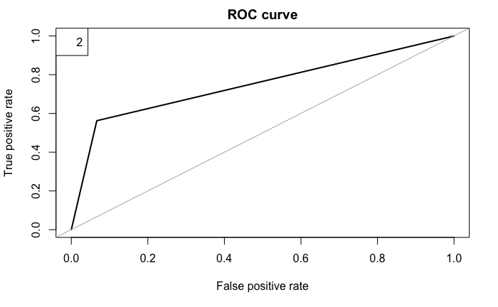

```
Area under the curve (AUC): 0.568

 confusion matrix


     0  1
  0  8  4
  1 10  9

 false positive percentage

[1] 32.25806

 recall:

[1] 0.5882353
```

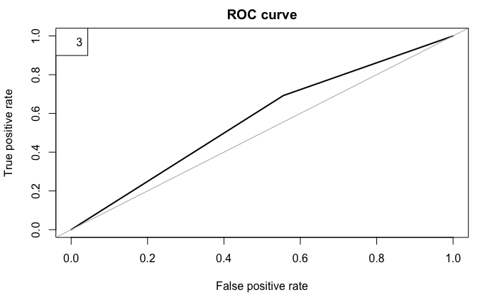

```
Area under the curve (AUC): 0.758

 confusion matrix


     0  1
  0 13  7
  1  1 10

 false positive percentage

[1] 3.225806

 recall:

[1] 0.6666667
```

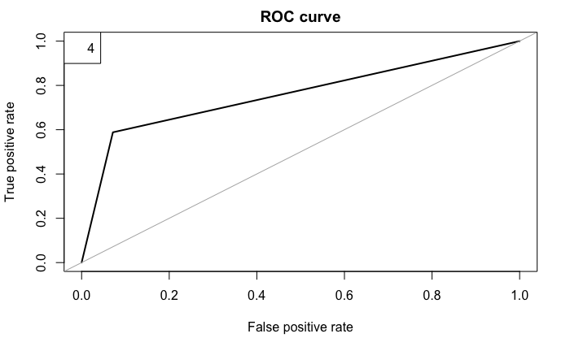

```
Area under the curve (AUC): 0.708

 confusion matrix


     0  1
  0 12  5
  1  4 10

 false positive percentage

[1] 12.90323
```

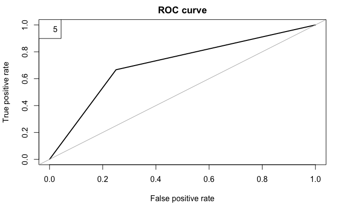

```r
fraud_balanced_under = fraud_balanced_under[sample(nrow(fraud_balanced_under)),]
folds = cut(seq(1,nrow(fraud_balanced_under)),breaks=5,labels=FALSE)
aucunder = c()
fppunder = c()
runder = c()
for(i in 1:5){

  testIndexes = which(folds==i,arr.ind=TRUE)

  testData = fraud_balanced_under[testIndexes, ]

  trainData = fraud_balanced_under[-testIndexes, ]

  treeunder = rpart(is_fraud ~ ., data = trainData)

  pred.treeunder = predict(treeunder, newdata = testData)

  cat("\n","recall:", "\n", "\n")

  print(accuracy.meas(testData$is_fraud, pred.treeunder[,2])$recall)

  cat("\n")

  print(roc.curve(testData$is_fraud, pred.treeunder[,2], plotit = TRUE))

  cat("\n","confusion matrix","\n","\n")

  tbunder = table(pred.treeunder[,2], testData$is_fraud)

  print(tbunder)

  legend("topleft", c("fold"), i)

  cat("\n","false positive percentage","\n", "\n")

  print((tbunder[2,1]/sum(tbunder))*100)

  runder = c(runder, accuracy.meas(testData$is_fraud, pred.treeunder[,2])$recall)

  aucunder = c(aucunder,roc.curve(testData$is_fraud, pred.treeunder[,2], plotit = FALSE)$auc)

  fppunder = c(fppunder,(tbunder[2,1]/sum(tbunder))*100)
}
```

```r
cat("\n","average recall", mean(runder), "\n")
```

```
 average recall 0.6096342
```

```r
cat("\n", "average AUC", mean(aucunder), "\n")
```

```
 average AUC 0.660452
```

```r
cat("\n", "average false positive percentage", mean(fppunder))
```

```
 average false positive percentage 16.12903
```

The under sampling technique, due to the very low number of observations in the training data set, led us to a very low performance, with very low recall and AUC.

The oversampling technique instead led us to a very good performance: with the 5 folds cross validation we have always obtained a recall of 1, namely we have been able to always detect all the “old frauds” on the test set, and we have obtained an average false positive percentage of 4.2615191 on the test set. This means that we have been able to find out all the previous frauds on the test set and also to discover 4.2615191 percent of “new frauds” that have been ignored by the “by hand” detection method.

Then the best method in order to find all the “old frauds” and to discover “new frauds” using a decision tree classifier is that of balancing the fraud_data set by over sampling the frauds. We can do a “visual check” for the around 4 percent of false positives discovered in the test data set in order to compare them with the true positives of the test set, namely with the old frauds.

```r
fraud_balanced_over = ovun.sample(is_fraud ~ ., data = fraud_data, method = "over", p=.5)$data
cat("\n","number of rows of the balanced data set:", "\n", "\n")
```

```
 number of rows of the balanced data set:
```

```r
nrow(fraud_balanced_over)
```

```
[1] 33701
```

```r
trainIndex = createDataPartition(fraud_balanced_over$is_fraud, p = .7, list = FALSE)
fraud_balanced_train = fraud_balanced_over[trainIndex,]
fraud_balanced_test = fraud_balanced_over[-trainIndex,]
treefinal = rpart(is_fraud ~ ., data = fraud_balanced_train)

pred.treefinal = predict(treefinal, newdata = fraud_balanced_test)

cat("\n","recall:", "\n", "\n")
```

```
 recall:
```

```r
print(accuracy.meas(fraud_balanced_test$is_fraud, pred.treefinal[,2])$recall)
```

```
[1] 1
```

```r
cat("\n")
```

```
Area under the curve (AUC): 0.955
```

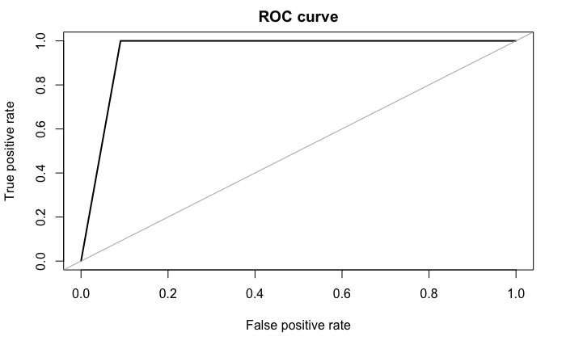

```r
print(roc.curve(fraud_balanced_test$is_fraud, pred.treefinal[,2], plotit = TRUE))
```

```r
cat("\n","confusion matrix","\n","\n")
```

```
 confusion matrix
```

```r
tbfinal = table(pred.treefinal[,2], fraud_balanced_test$is_fraud)

print(tbfinal)
```

```
       0    1
  0 4594    0
  1  459 5056
```

```r
cat("\n","false positive percentage","\n", "\n")
```

```
 false positive percentage
```

```r
print((tbfinal[2,1]/sum(tbfinal))*100)
```

```
[1] 4.540508
```

Visual representation of New Frauds vs Old Frauds

```r
fraud_balanced_test$predicted = pred.treefinal[,2]
new_fraud = fraud_balanced_test[fraud_balanced_test$is_fraud==0 & fraud_balanced_test$predicted==1,]
old_fraud = fraud_balanced_test[fraud_balanced_test$is_fraud==1,]
old_fraud = old_fraud[sample(nrow(old_fraud),nrow(new_fraud)),]
```

Comparison between Model distribution.

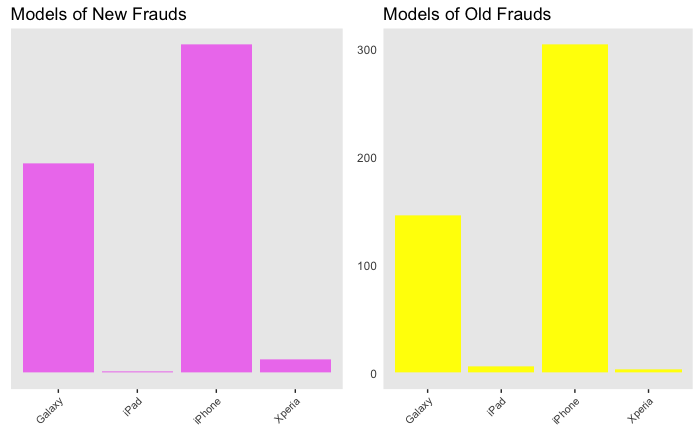

```r
plot1 = ggplot(new_fraud, aes(x = model)) + geom_bar(fill = "violet") + theme(axis.text.x = element_text(size  = 8, angle = 45, hjust = 1, vjust = 1)) + ggtitle("Models of New Frauds") + rremove("y.text") + rremove("ylab") + rremove("xlab") + rremove("grid") + rremove("y.ticks")
plot2 = ggplot(old_fraud, aes(x = model)) + geom_bar(fill = "yellow") + theme(axis.text.x = element_text(size  = 8, angle = 45, hjust = 1, vjust = 1)) + ggtitle("Models of Old Frauds") + rremove("ylab") + rremove("xlab") + rremove("grid") + rremove("y.ticks")
grid.arrange(plot1, plot2, ncol=2)
```

Comparison between Damage Reason distribution.

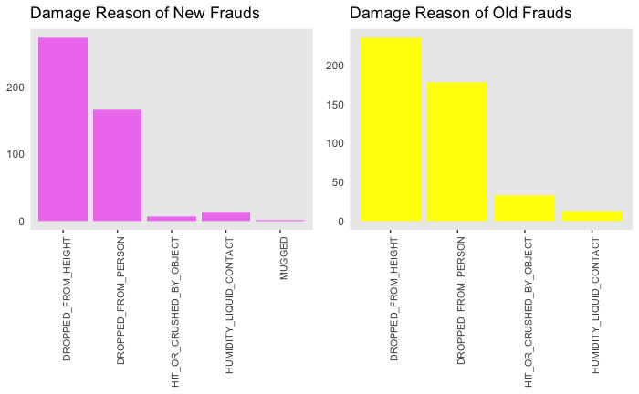

```r
plot1 = ggplot(new_fraud, aes(x = settlement_reason)) + geom_bar(fill = "violet") + theme(axis.text.x = element_text(size  = 8, angle = 90, hjust = 1, vjust = 1)) + ggtitle("Damage Reason of New Frauds") + rremove("ylab") + rremove("xlab") + rremove("grid") + rremove("y.ticks")
plot2 = ggplot(old_fraud, aes(x = settlement_reason)) + geom_bar(fill = "yellow") + theme(axis.text.x = element_text(size  = 8, angle = 90, hjust = 1, vjust = 1)) + ggtitle("Damage Reason of Old Frauds") + rremove("ylab") + rremove("xlab") + rremove("grid") + rremove("y.ticks")
grid.arrange(plot1, plot2, ncol=2)
```

Comparison between Status Before Closed distribution.

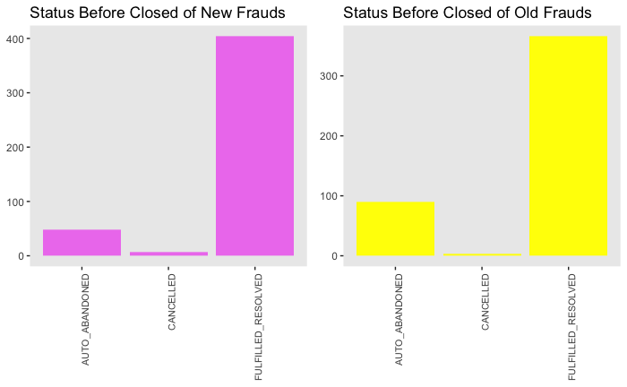

```r
plot1 = ggplot(new_fraud, aes(x = status_before_closed)) + geom_bar(fill = "violet") + theme(axis.text.x = element_text(size  = 8, angle = 90, hjust = 1, vjust = 1)) + ggtitle("Status Before Closed of New Frauds") + rremove("xlab") + rremove("ylab") + rremove("grid")
plot2 = ggplot(old_fraud, aes(x = status_before_closed)) + geom_bar(fill = "yellow") + theme(axis.text.x = element_text(size  = 8, angle = 90, hjust = 1, vjust = 1)) + ggtitle("Status Before Closed of Old Frauds") + rremove("xlab") + rremove("ylab") + rremove("grid")
grid.arrange(plot1, plot2, ncol=2)
```

Comparison between Contract Status distribution.

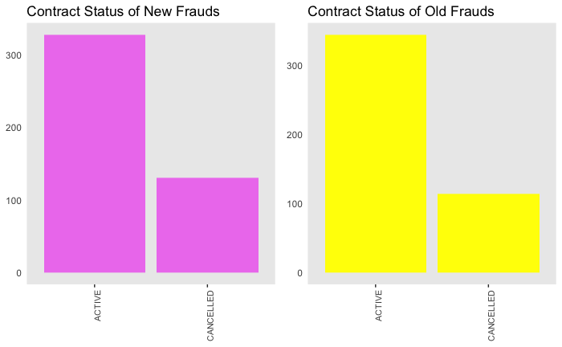

```r
plot1 = ggplot(new_fraud, aes(x = contract_status)) + geom_bar(fill = "violet") + theme(axis.text.x = element_text(size  = 8, angle = 90, hjust = 1, vjust = 1)) + ggtitle("Contract Status of New Frauds") + rremove("ylab") + rremove("xlab") + rremove("grid") + rremove("y.ticks")
plot2 = ggplot(old_fraud, aes(x = contract_status)) + geom_bar(fill = "yellow") + theme(axis.text.x = element_text(size  = 8, angle = 90, hjust = 1, vjust = 1)) + ggtitle("Contract Status of Old Frauds") + rremove("ylab") + rremove("xlab") + rremove("grid") + rremove("y.ticks")
grid.arrange(plot1, plot2, ncol=2)
```

Comparison between Proof of Purchase Required distribution.

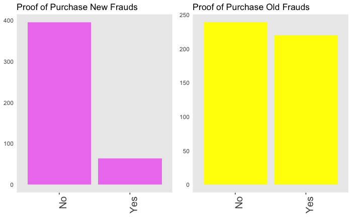

```r
plot1 = ggplot(new_fraud, aes(x = proof_purchase_required)) + geom_bar(fill = "violet") + theme(axis.text.x = element_text(size  = 15, angle = 90, hjust = 1, vjust = 1)) + ggtitle("Proof of Purchase New Frauds") + rremove("ylab") + rremove("xlab") + rremove("grid") + rremove("y.ticks")
plot2 = ggplot(old_fraud, aes(x = proof_purchase_required)) + geom_bar(fill = "yellow") + theme(axis.text.x = element_text(size  = 15, angle = 90, hjust = 1, vjust = 1)) + ggtitle("Proof of Purchase Old Frauds") + rremove("ylab") + rremove("xlab") + rremove("grid") + rremove("y.ticks")
grid.arrange(plot1, plot2, ncol=2)
```

Comparison between Pictures of Damage Required distribution.

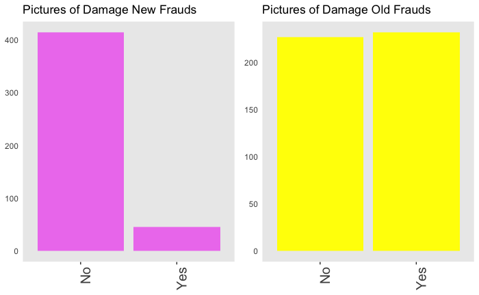

```r
plot1 = ggplot(new_fraud, aes(x = pictures_damage_required)) + geom_bar(fill = "violet") + theme(axis.text.x = element_text(size  = 15, angle = 90, hjust = 1, vjust = 1)) + ggtitle("Pictures of Damage New Frauds") + rremove("ylab") + rremove("xlab") + rremove("grid") + rremove("y.ticks")
plot2 = ggplot(old_fraud, aes(x = pictures_damage_required)) + geom_bar(fill = "yellow") + theme(axis.text.x = element_text(size  = 15, angle = 90, hjust = 1, vjust = 1)) + ggtitle("Pictures of Damage Old Frauds")  + rremove("ylab") + rremove("xlab") + rremove("grid") + rremove("y.ticks")
grid.arrange(plot1, plot2, ncol=2)
```

Comparison between Claim Caused By distribution.

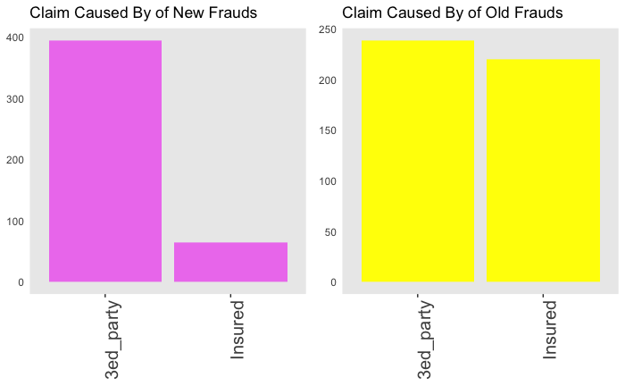

```r
plot1 = ggplot(new_fraud, aes(x = claim_caused_by)) + geom_bar(fill = "violet") + theme(axis.text.x = element_text(size  = 15, angle = 90, hjust = 1, vjust = 1)) + ggtitle("Claim Caused By of New Frauds") + rremove("ylab") + rremove("xlab") + rremove("grid") + rremove("y.ticks")
plot2 = ggplot(old_fraud, aes(x = claim_caused_by)) + geom_bar(fill = "yellow") + theme(axis.text.x = element_text(size  = 15, angle = 90, hjust = 1, vjust = 1)) + ggtitle("Claim Caused By of Old Frauds")  + rremove("ylab") + rremove("xlab") + rremove("grid") + rremove("y.ticks")
grid.arrange(plot1, plot2, ncol=2)
```

Comparison between Claim Created By distribution.

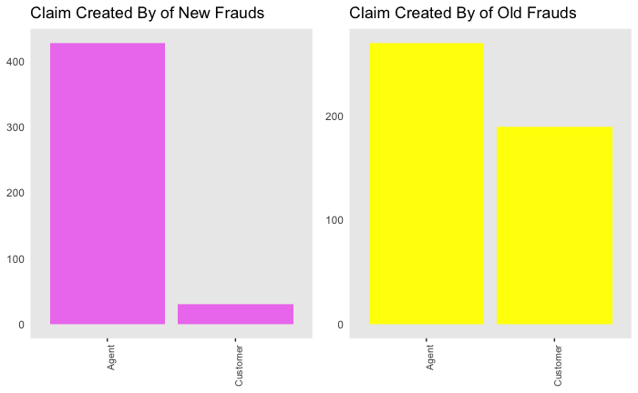

```r
plot1 = ggplot(new_fraud, aes(x = claim_created_by)) + geom_bar(fill = "violet") + theme(axis.text.x = element_text(size  = 8, angle = 90, hjust = 1, vjust = 1)) + ggtitle("Claim Created By of New Frauds") + rremove("ylab") + rremove("xlab") + rremove("grid") + rremove("y.ticks")
plot2 = ggplot(old_fraud, aes(x = claim_created_by)) + geom_bar(fill = "yellow") + theme(axis.text.x = element_text(size  = 8, angle = 90, hjust = 1, vjust = 1)) + ggtitle("Claim Created By of Old Frauds")  + rremove("ylab") + rremove("xlab") + rremove("grid") + rremove("y.ticks")
grid.arrange(plot1, plot2, ncol=2)
```

Comparison between Customer Language distribution.

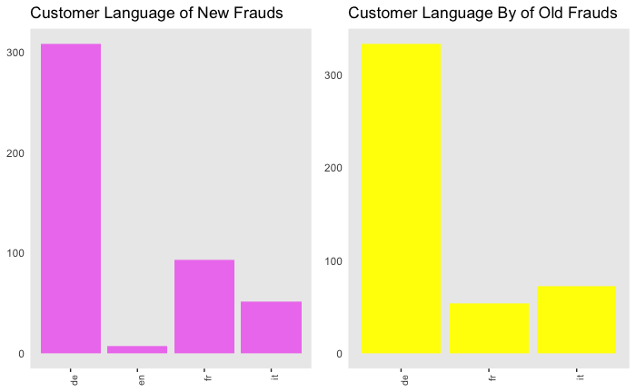

```r
plot1 = ggplot(new_fraud, aes(x = customer_language)) + geom_bar(fill = "violet") + theme(axis.text.x = element_text(size  = 8, angle = 90, hjust = 1, vjust = 1)) + ggtitle("Customer Language of New Frauds") + rremove("ylab") + rremove("xlab") + rremove("grid") + rremove("y.ticks")
plot2 = ggplot(old_fraud, aes(x = customer_language)) + geom_bar(fill = "yellow") + theme(axis.text.x = element_text(size  = 8, angle = 90, hjust = 1, vjust = 1)) + ggtitle("Customer Language By of Old Frauds")  + rremove("ylab") + rremove("xlab") + rremove("grid") + rremove("y.ticks")
grid.arrange(plot1, plot2, ncol=2)
```

Comparison between Make distribution.

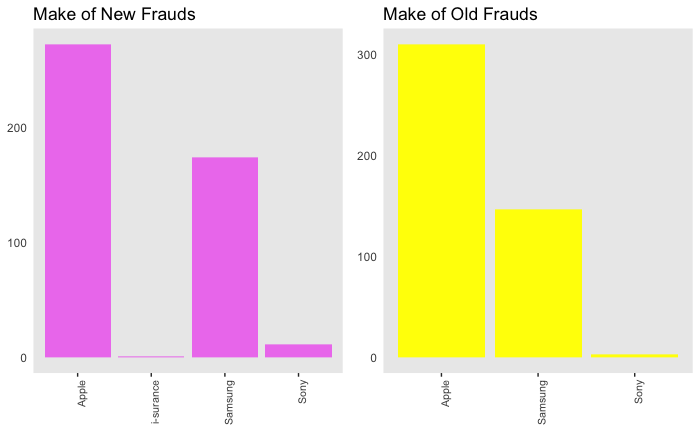

```r
plot1 = ggplot(new_fraud, aes(x = make)) + geom_bar(fill = "violet") + theme(axis.text.x = element_text(size  = 8, angle = 90, hjust = 1, vjust = 1)) + ggtitle("Make of New Frauds") + rremove("ylab") + rremove("xlab") + rremove("grid") + rremove("y.ticks")
plot2 = ggplot(old_fraud, aes(x = make)) + geom_bar(fill = "yellow") + theme(axis.text.x = element_text(size  = 8, angle = 90, hjust = 1, vjust = 1)) + ggtitle("Make of Old Frauds")  + rremove("ylab") + rremove("xlab") + rremove("grid") + rremove("y.ticks")
grid.arrange(plot1, plot2, ncol=2)
```

Comparison between Product Name distribution.

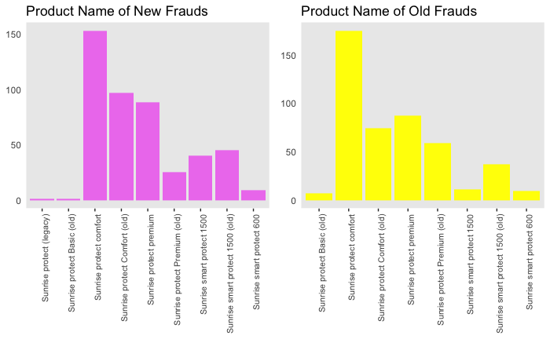

```r
plot1 = ggplot(new_fraud, aes(x = product_name)) + geom_bar(fill = "violet") + theme(axis.text.x = element_text(size  = 8, angle = 90, hjust = 1, vjust = 1)) + ggtitle("Product Name of New Frauds") + rremove("ylab") + rremove("xlab") + rremove("grid") + rremove("y.ticks")
plot2 = ggplot(old_fraud, aes(x = product_name)) + geom_bar(fill = "yellow") + theme(axis.text.x = element_text(size  = 8, angle = 90, hjust = 1, vjust = 1)) + ggtitle("Product Name of Old Frauds")  + rremove("ylab") + rremove("xlab") + rremove("grid") + rremove("y.ticks")
grid.arrange(plot1, plot2, ncol=2)
```

Comparison between Claim Device Memory distribution.

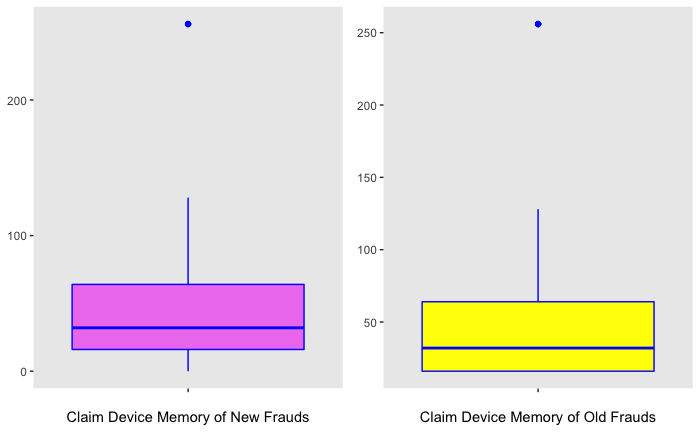

```r
plot1 = ggplot(new_fraud, aes(x = "", y = claim_device_memory)) + geom_boxplot(fill='violet', color='blue') + xlab("Claim Device Memory of New Frauds") + rremove("grid") + rremove("ylab")
plot2 = ggplot(old_fraud, aes(x = "", y = claim_device_memory)) + geom_boxplot(fill='yellow', color='blue') + xlab("Claim Device Memory of Old Frauds") + rremove("grid") + rremove("ylab")
grid.arrange(plot1, plot2, ncol=2)
```

Comparison between Fraud Reason distribution.

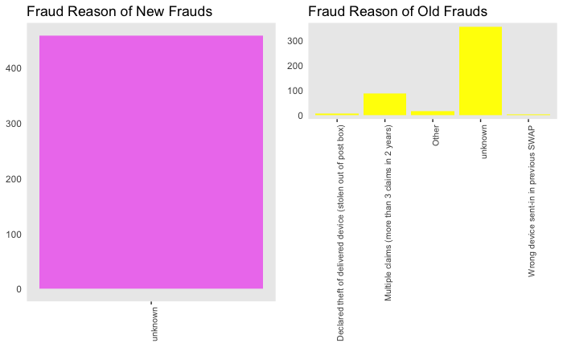

```r
plot1 = ggplot(new_fraud, aes(x = fraud_reason)) + geom_bar(fill = "violet") + theme(axis.text.x = element_text(size  = 8, angle = 90, hjust = 1, vjust = 1)) + ggtitle("Fraud Reason of New Frauds") + rremove("ylab") + rremove("xlab") + rremove("grid") + rremove("y.ticks")
plot2 = ggplot(old_fraud, aes(x = fraud_reason)) + geom_bar(fill = "yellow") + theme(axis.text.x = element_text(size  = 8, angle = 90, hjust = 1, vjust = 1)) + ggtitle("Fraud Reason of Old Frauds") + rremove("ylab") + rremove("xlab") + rremove("grid") + rremove("y.ticks")
grid.arrange(plot1, plot2, ncol=2)
```

Comparison between Claim Rejection Reason distribution.

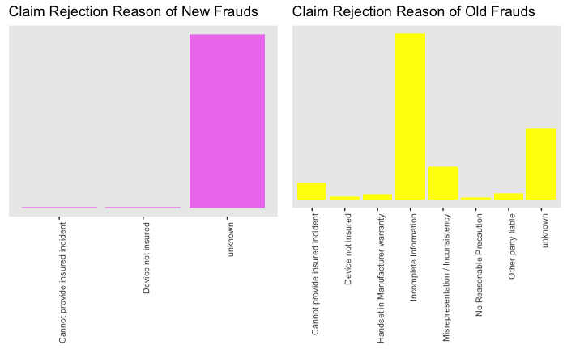

```r
plot1 = ggplot(new_fraud, aes(x = claim_rejection_reason)) + geom_bar(fill = "violet") + theme(axis.text.x = element_text(size  = 8, angle = 90, hjust = 1, vjust = 1)) + ggtitle("Claim Rejection Reason of New Frauds") + rremove("y.text") + rremove("ylab") + rremove("xlab") + rremove("grid") + rremove("y.ticks")
plot2 = ggplot(old_fraud, aes(x = claim_rejection_reason)) + geom_bar(fill = "yellow") + theme(axis.text.x = element_text(size  = 8, angle = 90, hjust = 1, vjust = 1)) + ggtitle("Claim Rejection Reason of Old Frauds") + rremove("y.text") + rremove("ylab") + rremove("xlab") + rremove("grid") + rremove("y.ticks")
grid.arrange(plot1, plot2, ncol=2)
```

Besides the visual representation, we want to find a sort of “characterization” of frauds (both for the old ones and for the new ones) dictated by machine learning criteria. How much do the criteria used by the machine differ from the “by hand” criteria?

- We will first create a new data set, “fraud_balanced”, by labelling as frauds also the new frauds in the test set and by deleting the column named “predicted”.
- Then we will run a cross validated lasso logistic regression as a first way to select the important features to predict the frauds.
- Finally we will run a random forest as another way to assign a measure of importance to the features needed to predict the frauds.

```r
fraud_balanced_test$is_fraud[fraud_balanced_test$predicted == 1] = 1
fraud_balanced = fraud_balanced_test[,-ncol(fraud_balanced_test)]
```

Final percentage of frauds in the balanced fraud set.

```r
sum(fraud_balanced$is_fraud==1)*100/nrow(fraud_balanced)
```

```
[1] 54.55535
```

1. Logistic regression and lasso regression

Let’s assume that the outcome (predicted variable) and predictors are denoted by Y and X respectively and the two classes of interest are denoted by + and – respectively. We wish to model the conditional probability that the outcome Y is +, given that the input variables (predictors) are X. The conditional probability is denoted by $p(Y=+|X)$ which we’ll abbreviate as $p(X)$ since we know we are referring to the positive outcome Y=+. We are after the probability of class membership so we must ensure that the hypothesis function always lies between 0 and 1. The function assumed in logistic regression is:
$$p(X) = \dfrac{\exp^{\beta_0+\beta_1 X}}{1+\exp^{\beta_0 + \beta_1 X}}$$
An equivalent way of expressing the above equation is:
$$\log\left(\dfrac{p(X)}{1-p(X)}\right) = \beta_0+\beta_1 X$$
The quantity on the left is the logarithm of the odds. So, the model is a linear regression of the log-odds, sometimes called logit, and hence the name logistic regression.
The problem is to find the values of $\beta_0$ and $\beta_1$ that results in a $p(X)$ that most accurately classifies all the observed data points – that is, those that belong to the positive class have a probability as close as possible to 1 and those that belong to the negative class have a probability as close as possible to 0. One way to frame this problem is to say that we wish to maximize the product of these probabilities, often referred to as the likelihood:
$${\prod_{i:Y_i=+} p(X_{i}) \prod_{j:Y_j=-}(1-p(X_{j}))}$$
where $\prod$ represents the products over i and j, which run over the +ve and –ve classed points respectively. This approach, called maximum likelihood estimation, is quite common in many machine learning settings, especially those involving probabilities. In practice one works with the log of the likelihood, because it is easier to work with mathematically. Moreover, one minimizes the negative log likelihood which, of course, is the same as maximizing the log likelihood. The quantity one minimizes is thus:
$$L = -\log\left( {\prod_{i:Y_i=+} p(X_{i}) \prod_{j:Y_j=-}(1-p(X_{j}))}\right)$$
Ridge and Lasso regularization work by adding a penalty term to the log likelihood function. In the case of ridge regression, the penalty term is $\beta_1^2$ and in the case of lasso, it is $|\beta_1|$, where $\beta_1$ is a vector, with as many components as there are predictors.
The quantity to be minimized in the two cases is thus:
$$L +\lambda \sum \beta_1^2$$
for ridge regression and
$$L +\lambda \sum |\beta_1|$$
for lasso regression, where $\lambda$ is a free parameter which is usually selected in such a way that the resulting model minimizes the out of sample error.
In the case of ridge regression, the effect of the penalty term is to reduce the coefficients that contribute most to the error. In other words, it reduces the magnitude of the coefficients that contribute to increasing L. In contrast, in the case of lasso regression, the effect of the penalty term is to set the these coefficients exactly to zero. So Lasso regression works like a feature selector that picks out the most important coefficients, i.e. those that are most predictive, in other words that have the lowest p-values. (The p-value for each term tests the null hypothesis that the coefficient is equal to zero, i.e. no effect on the outcome. A low p-value, < 0.05, indicates that one can reject the null hypothesis. In other words, a predictor that has a low p-value is likely to be a meaningful addition to the model because changes in the predictor’s value are related to changes in the response variable).
Ridge and Lasso are regularization tecniques used to reduce the complexity of the model. Now, since the size of coefficients increase exponentially with increase in model complexity, putting a constraint on the magnitude of coefficients (as in Ridge and Lasso) is one of the ways to reduce model complexity. Note that a large coefficient means that we are putting a lot of emphasis on that feature, i.e. the particular feature is a good predictor for the outcome. So, when the coefficient becomes too large, the algorithm starts modelling intricate relations to estimate the output and ends up overfitting to the particular training data.

```r
fraud_balanced = fraud_balanced[sample(nrow(fraud_balanced)),]
drops = c("device_type","claim_number","claim_id","claim_device_memory","claim_created_by","customer_number","contract_number","claim_date","device_creation_date","reported_at","what_happened","claim_scene","city","claim_type","claim_caused_by","contract_status","pictures_damage_required","proof_purchase_required")
fraud_balanced = fraud_balanced[,!(names(fraud_balanced) %in% drops)]
folds = cut(seq(1,nrow(fraud_balanced)),breaks=5,labels=FALSE)
ac = c()
for(i in 1:5){

  testIndexes = which(folds==i,arr.ind=TRUE)

  testData = fraud_balanced[testIndexes, ]

  trainData = fraud_balanced[-testIndexes, ]

  x_train = model.matrix(is_fraud~ ., data=trainData,contrasts.arg=lapply(trainData, contrasts, contrasts=FALSE))
  y_train = trainData$is_fraud
  lasso = glmnet(x_train,y_train, family = "binomial", alpha=1, lambda=0.01) # alpha=0 for ridge, alpha=1 for lasso
  cat("\n","coefficients for fold", i,"\n", "\n")

  print(coef(lasso))

  print(lasso)

  x_test = model.matrix(is_fraud~ ., data=testData,contrasts.arg=lapply(testData, contrasts, contrasts=FALSE))

  lasso_prob = predict(lasso, newx = x_test, type="response")
  #translate probabilities to predictions

  predlasso = ifelse(lasso_prob>.5, 1, 0)

  cat("\n","confusion matrix for fold", i,"\n", "\n")

  print(table(pred=predlasso,true=testData$is_fraud))

  cat("\n","accuracy for fold", i,"\n", "\n")

  print(mean(predlasso==testData$is_fraud))

  ac = c(ac,mean(predlasso==testData$is_fraud))
}
```

```
 coefficients for fold 1

101 x 1 sparse Matrix of class "dgCMatrix"
                                                                                s0
(Intercept)                                                              9.1483243
(Intercept)                                                              .
product_nameSunrise call protect                                         .
product_nameSunrise protect (legacy)                                     .
product_nameSunrise protect basic                                        .
product_nameSunrise protect Basic (old)                                  .
product_nameSunrise protect comfort                                      .
product_nameSunrise protect Comfort (old)                                .
product_nameSunrise protect premium                                      .
product_nameSunrise protect Premium (old)                                .
product_nameSunrise smart protect 1500                                   .
product_nameSunrise smart protect 1500 (old)                             .
product_nameSunrise smart protect 400                                    .
product_nameSunrise smart protect 600                                    .
makeApple                                                                .
makeBlackberry                                                           .
makehtc                                                                  .
makeHuawei                                                               .
makei-surance                                                            .
makeLG                                                                   .
makeLocal                                                                .
makeMicrosoft                                                            .
makeMotorola                                                             .
makeNokia                                                                .
makeSamsung                                                              .
makeSony                                                                 .
makeSunrise                                                              .
makeunknown                                                              .
claim_device_makeApple                                                   .
claim_device_makeBlackberry                                              .
claim_device_makeHuawei                                                  .
claim_device_makeInsurance                                               .
claim_device_makeLG                                                      .
claim_device_makeLocal                                                   .
claim_device_makeMicrosoft                                               .
claim_device_makeMotorola                                                .
```

[output cut: 554 more lines]

```
Call:  glmnet(x = x_train, y = y_train, family = "binomial", alpha = 1,      lambda = 0.01)

     Df  %Dev Lambda
[1,]  5 0.751   0.01

 confusion matrix for fold 5

    true
pred    0    1
   0  898   95
   1    7 1022

 accuracy for fold 5

[1] 0.9495549
```

```r
cat("\n","mean accuracy","\n", "\n")
```

```
 mean accuracy
```

```r
print(mean(ac))
```

```
[1] 0.9514296
```

2. Random Forest

Random Forests is a learning method for classification (or regression) and is essentially a collection of Decision Trees. A decision tree is built on an entire data set, using all the variables of interest, whereas a random forest randomly selects rows and specific variables to build multiple decision trees from and then averages the results. After a large number of trees are built using this method, each tree “votes” or chooses the class, and the class receiving the most votes by a simple majority is the predicted class. Random forest algorithms also give measures of variable importance. For this algorithm we are using mean decrease in Gini as measure of variable importance.

When determining splits in individual trees, the algorithm looks for the largest class (in terms of population) and attempts to isolate it first. If this is not possible, it tries to do the best it can, always focusing on isolating the largest remaining class in every split. This is called the Gini splitting rule. The “goodness of split” is measured by the Gini Impurity, $I_{G}$. For a set containing $K$ categories this is given by:
$$I_{G} = \sum_{i=1}^{K} f_{i}(1-f_{i})$$
where $f_{i}$ is the fraction of the set that belongs to the $i_{th}$ category. Clearly, $I_{G}$ is 0 when the set is homogeneous or pure (1 class only) and is maximum when classes are equiprobable (for example, in a two class set the maximum occurs when $f_{1}$ and $f_{2}$ are 0.5). At each stage the algorithm chooses to split on the predictor that leads to the largest decrease in $I_{G}$. The algorithm tracks this decrease for each predictor for all splits and all trees in the forest. The average is reported as the mean decrease in Gini.

```
 number of trees for fold 1

[1] 500

 variable importance for fold 1


 confusion matrix for fold 1


predrf    0    1
     0  898  103
     1    0 1021

 accuracy for fold 1

[1] 0.9490603

 number of trees for fold 2

[1] 500

 variable importance for fold 2
```

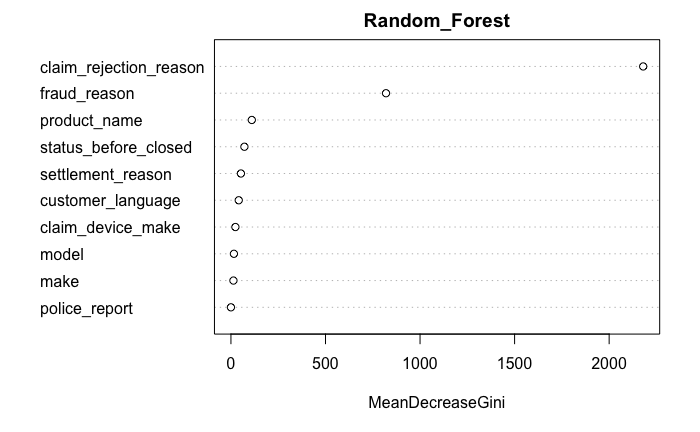

```
 confusion matrix for fold 2


predrf   0   1
     0 940  85
     1   1 996

 accuracy for fold 2

[1] 0.9574679

 number of trees for fold 3

[1] 500

 variable importance for fold 3
```

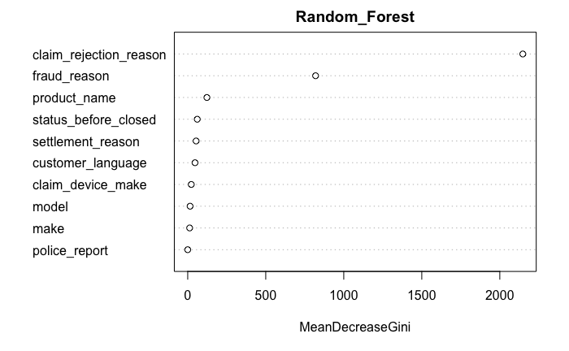

```
 confusion matrix for fold 3


predrf   0   1
     0 944  86
     1   2 989

 accuracy for fold 3

[1] 0.9564572

 number of trees for fold 4

[1] 500

 variable importance for fold 4
```

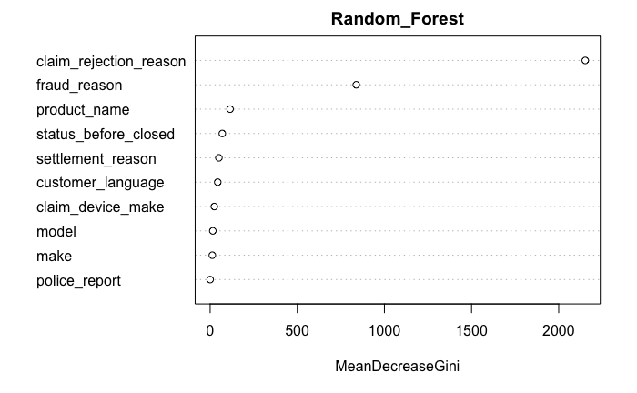

```
 confusion matrix for fold 4


predrf    0    1
     0  895   96
     1    0 1031

 accuracy for fold 4

[1] 0.9525223

 number of trees for fold 5

[1] 500

 variable importance for fold 5
```

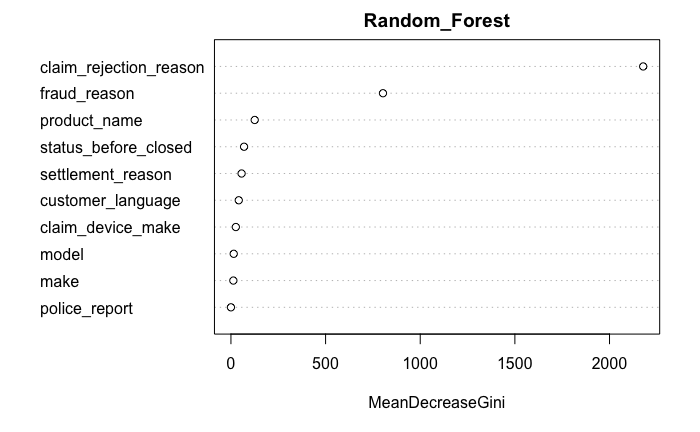

```
 confusion matrix for fold 5


predrf    0    1
     0  912   89
     1    2 1019

 accuracy for fold 5

[1] 0.9549951
```

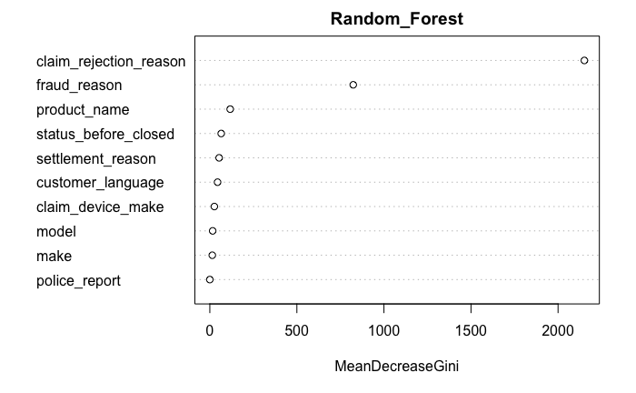

```r
fraud_balanced = fraud_balanced[sample(nrow(fraud_balanced)),]
drops = c("device_type","claim_number","claim_id","claim_device_memory","customer_number","contract_number","claim_date","device_creation_date","reported_at","what_happened","claim_scene","city")
fraud_balanced = fraud_balanced[,!(names(fraud_balanced) %in% drops)]
folds = cut(seq(1,nrow(fraud_balanced)),breaks=5,labels=FALSE)
ac = c()
for(i in 1:5){

  testIndexes = which(folds==i,arr.ind=TRUE)

  testData = fraud_balanced[testIndexes, ]

  trainData = fraud_balanced[-testIndexes, ]

  Random_Forest = randomForest(is_fraud ~ ., data=trainData)

  predrf = predict(Random_Forest, newdata = testData, importance=TRUE)
  importance(Random_Forest, type=1)

  cat("\n","number of trees for fold", i,"\n", "\n")
  print(Random_Forest$ntree)
  cat("\n","variable importance for fold", i,"\n", "\n")

  #print(str(rf_classifier$importance))

  varImpPlot(Random_Forest)

  cat("\n","confusion matrix for fold", i,"\n", "\n")
  tbrf = table(predrf, testData$is_fraud)
  print(tbrf)

  cat("\n","accuracy for fold", i,"\n", "\n")

  print(mean(predrf==testData$is_fraud))

  ac = c(ac,mean(predrf==testData$is_fraud))
}
```

```r
cat("\n","mean accuracy","\n", "\n")
```

```
 mean accuracy
```

```r
print(mean(ac))
```

```
[1] 0.9541005
```

With respect to the “by hand” detection, the Random Forest algorithm confirms that “claim_rejection_reason”, “fraud_reason”, “status_before_closed” are three of the most important variables to identify a fraud and also gives us new variables to keep an eye on when searching for frauds as, for example, “product name”, “settlement_reason” and “costumer_language”.